# DATA MINING ASSIGNMENT 3

## Document Classification

```python
import glob

read_files_comedy = glob.glob("comedy/*.txt")

with open( 'comedy_all.txt', 'w' ) as result:
    for file_ in read_files_comedy:
        for line in open( file_, 'r' ):
            result.write( line )

read_files_history = glob.glob("history/*.txt")

with open( 'history_all.txt', 'w' ) as result:
    for file_ in read_files_history:
        for line in open( file_, 'r' ):
            result.write( line )

read_files_tragedy = glob.glob("tragedy/*.txt")

with open( 'tragedy_all.txt', 'w' ) as result:
    for file_ in read_files_tragedy:
        for line in open( file_, 'r' ):
            result.write( line )
# we have three seperate files that have concatenated text from files belonging to each catagories

classes = [
    'comedy',
    'history',
    'tragedy',
    ]

#reading the concatenated text from each class
with open('comedy_all.txt', 'r') as myfile:
    comedy_all_read=myfile.read().replace('\n', '')
with open('tragedy_all.txt', 'r') as myfile:
    tragedy_all_read=myfile.read().replace('\n', '')
with open('history_all.txt', 'r') as myfile:
    history_all_read=myfile.read().replace('\n', '')
```

**Creating vector of words for each class**

```python
# creating a vector of each class
import re

comedy_all_read=re.sub(r'[?|"\'"|$|&|:|.|!|,|-|;]',r'',comedy_all_read)
comedy_all_split=comedy_all_read.split()
comedy_unique_words=set(comedy_all_split)

history_all_read=re.sub(r'[?|"\'"|$|&|:|.|!|,|-|;]',r'',history_all_read)
history_all_split=history_all_read.split()
history_unique_words=set(history_all_split)

tragedy_all_read=re.sub(r'[?|"\'"|$|&|:|.|!|,|-|;]',r'',tragedy_all_read)
tragedy_all_split=tragedy_all_read.split()
tragedy_unique_words=set(tragedy_all_split)

print "Showing the first 10 elements in the vector"
cl=list(comedy_unique_words)
print "class:",classes[0],"\n",cl[:10]
```

```
Showing the first 10 elements in the vector
class: comedy
['fawn', 'thus--to', 'pityyou', 'cordTherefore', 'mustachio', 'itShall', 'hitherBreak', 'spiders', 'hanging', 'dieFor']
```

```python
hl=list(history_unique_words)
print "Showing the first 10 elements in the vector"
print "class:",classes[1],"\n",hl[:10]
```

```
Showing the first 10 elements in the vector
class: history
['fawn', 'mustachio', 'fitAnd', 'itShall', 'woods', 'spiders', 'hanging', 'maliceIm', 'dieFor', 'worldIs']
```

```python
tl=list(tragedy_unique_words)
print "Showing the first 10 elements in the vector"
print "class:",classes[2],"\n",tl[:10]
```

```
Showing the first 10 elements in the vector
class: tragedy
['fawn', 'giveMethinks', 'nunnery', 'andSweet-heart', 'afootNoble', 'chameleons', 'spiders', 'hanging', 'travelFulvia', 'dieFor']
```

**Removing Stop words from the documents**

```python
# stop words removal

with open('stopwords.txt','r') as source:
    stopwords=source.read().split()
stopwords=list(stopwords)

comedy_stword_removed=[]
history_stword_removed=[]
tragedy_stword_removed=[]

for word in (i.lower() for i in comedy_all_split):
    if word not in stopwords:
        comedy_stword_removed.append(word)

for word in (i.lower() for i in tragedy_all_split):
    if word not in stopwords:
        tragedy_stword_removed.append(word)

for word in (i.lower() for i in history_all_split):
    if word not in stopwords:
        history_stword_removed.append(word)
# we have a list for three classes comedy, tragedy and history with stop words removed from them
```

```python
# term document matrix

with open('comedy_stword_removed.txt', 'w') as out_file:
    out_file.write(' '.join(comedy_stword_removed))

with open('tragedy_stword_removed.txt', 'w') as out_file:
    out_file.write(' '.join(tragedy_stword_removed))

with open('history_stword_removed.txt', 'w') as out_file:
    out_file.write(' '.join(history_stword_removed))
```

**We are creating aTerm Document Matrix for all the words in each document under three classes after removing stopwords and punctuations manually**

```python
import pandas as pd
comedyDic=dict.fromkeys(comedy_stword_removed,0)
tragedyDic=dict.fromkeys(tragedy_stword_removed,0)
historyDic=dict.fromkeys(history_stword_removed,0)

for word in comedy_stword_removed:
    comedyDic[word]+=1
for word in tragedy_stword_removed:
    tragedyDic[word]+=1
for word in history_stword_removed:
    historyDic[word]+=1

pd.DataFrame([comedyDic,historyDic,tragedyDic],index=classes).fillna(0)
```

|  | 2ditem | 2s | 4ditem | 5s | 6ditem | 8ditem | a--uncertain | a-bed | a-beda | a-bedhe | ... | zealwe | zed | zephyrs | zir | zo | zodiacs | zonemake | zounds | zoundsi | zwaggered |
| --- | --- | --- | --- | --- | --- | --- | --- | --- | --- | --- | --- | --- | --- | --- | --- | --- | --- | --- | --- | --- | --- |
| comedy | 0 | 0 | 0 | 0 | 0 | 0 | 1 | 0 | 1 | 0 | ... | 0 | 0 | 1 | 0 | 0 | 1 | 0 | 0 | 0 | 0 |
| history | 1 | 2 | 1 | 1 | 1 | 1 | 0 | 0 | 0 | 0 | ... | 1 | 0 | 0 | 0 | 0 | 0 | 0 | 3 | 1 | 0 |
| tragedy | 0 | 0 | 0 | 0 | 0 | 0 | 0 | 2 | 0 | 1 | ... | 0 | 1 | 0 | 2 | 1 | 0 | 1 | 2 | 0 | 1 |

3 rows × 81296 columns

## Multinomial Niave Bayes classification

```python
from sklearn.naive_bayes import MultinomialNB
from sklearn.feature_extraction import DictVectorizer
from sklearn.feature_extraction.text import CountVectorizer
from sklearn.datasets import load_files
category=['comedy','history','tragedy']
doc_training=load_files('doc_train/',categories=category,encoding='UTF-8',random_state=45,shuffle=True)
doc_testing=load_files('doc_test/',encoding='UTF-8',random_state=45)
```

```python
vectorizer = CountVectorizer(min_df=1) # making a feature vector
x_train=vectorizer.fit_transform(doc_training.data) #converting data into numerical form
y_train=doc_training.target
x_train
```

```
<28x20493 sparse matrix of type '<type 'numpy.int64'>'
	with 97306 stored elements in Compressed Sparse Row format>
```

```python
cls_multi=MultinomialNB(alpha=1).fit(x_train,y_train)
print("Training score: {0:.1f}%".format(cls_multi.score(x_train,y_train)*100))
```

```
Training score: 100.0%
```

```python
x_test=vectorizer.transform(doc_testing.data)
x_test
```

```
<2x20493 sparse matrix of type '<type 'numpy.int64'>'
	with 5641 stored elements in Compressed Sparse Row format>
```

**Prediction results**

```python
result=cls_multi.predict(x_test)
print "the two documents are classified as:",result
```

```
the two documents are classified as: [0 2]
```

```python
value=doc_training.target_names # this is the names of the three classes
doc_list=['c10.txt','t10.txt']
v=[]
for i in result:
        v.append(value[i])
col=['test docs']
pd.DataFrame(doc_list,columns=col,index=v)
```

|  | test docs |
| --- | --- |
| comedy | c10.txt |
| tragedy | t10.txt |

### Probabilties for each class based on Multinomial NB

```python
cl_prob=cls_multi.predict_proba(x_test)
cl_prob
```

```
array([[  1.00000000e+000,   0.00000000e+000,   0.00000000e+000],
       [  0.00000000e+000,   6.01830708e-137,   1.00000000e+000]])
```

*In the above array, the three columns are Probabilities of documents given the class 'comedy','history' and 'tragedy'*

P(c10|comedy), P(c10|history), P(c10|tragedy)  
P(t10|comedy) P(t10|history) P(t10|tragedy)

first row= c10.txt  
second row=t10.txt  
*so c10 has probablity of 1 for comedy and 0 for the remaining two classes t10 has probablity of 1 for class tragedy and 0 for the remaining two classes*

```python
ccol=['P(doc|comedy)', 'P(doc|history)', 'P(doc|tragedy)' ]
cdf=pd.DataFrame([[1,0,0],[0,0,1]],index=['c10.txt','t10.txt'])
cdf.columns=ccol
cdf
```

|  | P(doc\|comedy) | P(doc\|history) | P(doc\|tragedy) |
| --- | --- | --- | --- |
| c10.txt | 1 | 0 | 0 |
| t10.txt | 0 | 0 | 1 |

```python
cls_multi.predict_log_proba(x_test)
```

```
array([[    0.        , -2003.53878218, -1223.96254318],
       [-1377.67465944,  -313.65935174,     0.        ]])
```

```python
ccol2=['P(doc|comedy)', 'P(doc|history)', 'P(doc|tragedy)' ]
cdf2=pd.DataFrame([[0,-2003.53,-1223.96],[-1377.67,-313.65,0]],index=['c10.txt','t10.txt'])
cdf2.columns=ccol2
cdf2
```

|  | P(doc\|comedy) | P(doc\|history) | P(doc\|tragedy) |
| --- | --- | --- | --- |
| c10.txt | 0.00 | -2003.53 | -1223.96 |
| t10.txt | -1377.67 | -313.65 | 0.00 |

*similar to probability which gives values ranging from 0 to 1 , we can scale them to higher integer values with log to prevent underflow errors. In this case, the value '0' is the highest value since the other values are negative.*

## Bernoulli model of Naive Bayes

```python
from sklearn.naive_bayes import BernoulliNB
cls_bn=BernoulliNB(alpha=1).fit(x_train,y_train)
print("Training score: {0:.1f}%".format(cls_bn.score(x_train,y_train)*100))
```

```
Training score: 100.0%
```

```python
res_bn=cls_bn.predict(x_test) #predicting the classes using the Bernoulli model
print "the two documents are classified as:",res_bn
```

```
the two documents are classified as: [0 1]
```

```python
value1=doc_training.target_names # this is the names of the three classes
doc_list1=['c10.txt','t10.txt']
v1=[]
for i in res_bn:
        v1.append(value1[i])
colcol=['test docs']
pd.DataFrame(doc_list1,columns=colcol,index=v1)
```

|  | test docs |
| --- | --- |
| comedy | c10.txt |
| history | t10.txt |

*The Beroulli classifier has classified c10 as comedy and t10 as history. This prediction is different from the Mulitnomial classification*

### Probablities of documents under each class based on Bernoulli

```python
clber_prob=cls_bn.predict_proba(x_test)
clber_prob
```

```
array([[  1.00000000e+000,   1.03013378e-171,   9.63473745e-168],
       [  1.62526185e-081,   1.00000000e+000,   1.34616590e-091]])
```

```python
ccol1=['P(doc|comedy)', 'P(doc|history)', 'P(doc|tragedy)' ]
cdf1=pd.DataFrame([[1,0,0],[0,1,0]],index=['c10.txt','t10.txt'])
cdf1.columns=ccol1
cdf1
```

|  | P(doc\|comedy) | P(doc\|history) | P(doc\|tragedy) |
| --- | --- | --- | --- |
| c10.txt | 1 | 0 | 0 |
| t10.txt | 0 | 1 | 0 |

*This classifier has predicted that c10 is comedy and t10 is history*

```python
cls_bn.predict_log_proba(x_test)
```

```
array([[   0.        , -393.71236222, -384.56892057],
       [-186.02372359,    0.        , -209.23798299]])
```

```python
ccol3=['P(doc|comedy)', 'P(doc|history)', 'P(doc|tragedy)' ]
cdf3=pd.DataFrame([[0,-393.71,-384.56],[-186.02,0,-209.23]],index=['c10.txt','t10.txt'])
cdf3.columns=ccol3
cdf3
```

|  | P(doc\|comedy) | P(doc\|history) | P(doc\|tragedy) |
| --- | --- | --- | --- |
| c10.txt | 0.00 | -393.71 | -384.56 |
| t10.txt | -186.02 | 0.00 | -209.23 |

## Stop words from Shakespeare?

2) Shakespeare's vocabulary is pretty unique and he uses many archaic words. Even for simple terms ,eg:  
thy,thou for you, other examples are like hast, whence,wherefore,yonder,nay,aye  
These words are common words that do not really carry useful information to learn from.  
On the other hand,Stop words are the words that add little or no semantic value to the sentance. They are the words that can be removed without loss of information while training the classifier. We can conclude that with Shakespeare's unique vocabulary of many common words , it is safe to assume that they (words like hast,ye,thou,art,nay) can be added to the stop words.It may not be of much use when we classify text from recent years. But it would make sense to add his unique words that carry no datamining value.

## Spam Classification

```python
import pandas as pd
import numpy as np
spam_original=pd.DataFrame.from_csv('spam.csv',sep=',',index_col=None)
spam=spam_original.drop(['isuid','id','domain','spampct','category','cappct'],axis=1)
cols=spam.columns.drop('spam')
spam.replace('Mon', 1,inplace=True)
spam.replace('Tue', 2,inplace=True)
spam.replace('Wed', 3,inplace=True)
spam.replace('Thu', 4, inplace=True)
spam.replace('Fri', 5,inplace=True)
spam.replace('Sat', 6,inplace=True)
spam.replace('Sun', 7,inplace=True)
spam.replace('yes', 1,inplace=True)
spam.replace('no', 0,inplace=True)
spam.replace('name', 2,inplace=True)
spam.replace('single', 1,inplace=True)
spam.replace('empty', 0,inplace=True)

spam.shape
```

```
(2171, 15)
```

```python
#convert datarame to numpy array
spam_numpy=spam.as_matrix()
spam_numpy.shape
```

```
(2171L, 15L)
```

```python
#shuffle and split training-testing sets

#training set definition
np.random.shuffle(spam_numpy)
training15= spam_numpy[:int(len(spam_numpy) * 0.8), :]
training_x=training15[:,:14]
print "entire training set:",training15.shape
print "training set after class removed:",training_x.shape
training_y=training15[:,-1:]
print "training class label:",training_y.shape
train_y=training_y.reshape(len(training_y),)
# test set definition
testing15=spam_numpy[int(len(spam_numpy)*-0.2):,:]
testing_x=testing15[:,:14]
testing_y=testing15[:,-1:]
print "entire testing set:",testing15.shape
print "testing set after class removed:",testing_x.shape
print "testing class label",testing_y.shape
```

```
entire training set: (1736L, 15L)
training set after class removed: (1736L, 14L)
training class label: (1736L, 1L)
entire testing set: (434L, 15L)
testing set after class removed: (434L, 14L)
testing class label (434L, 1L)
```

## Naive Bayes Classification

```python
from sklearn.naive_bayes import GaussianNB
gnb = GaussianNB()
gnb=gnb.fit(training_x,train_y)
ypred_nb = gnb.predict(testing_x)
```

**Accuracy**

```python
from sklearn.metrics import accuracy_score
print "The accuracy of our classifier is:",accuracy_score(testing_y,ypred_nb)
Accuracy_NaiveBayes=accuracy_score(testing_y,ypred_nb)*100
```

```
The accuracy of our classifier is: 0.89400921659
```

The accuracy is almost 90% which means the calssifier is good in prediciting spam labels (or not spam labels)

**Error Estimation**

```python
from sklearn.metrics import mean_absolute_error
from sklearn.metrics import mean_squared_error
print "Mean Absolute Error in the predication:",mean_absolute_error(testing_y,ypred_nb)
print "Mean Squared Error in the predication:",mean_squared_error(testing_y,ypred_nb)
MAE_NaiveBayes=mean_absolute_error(testing_y,ypred_nb)*100
MSE_NaiveBayes=mean_absolute_error(testing_y,ypred_nb)*100
```

```
Mean Absolute Error in the predication: 0.10599078341
Mean Squared Error in the predication: 0.10599078341
```

**AUC Performance**

```
Area under the curve based on prediction: 0.847410660602
False positive rate: [0.0, 0.04501607717041801, 1.0]
True positive rate: [0.0, 0.7398373983739838, 1.0]
threshold: [2 1 0]
```

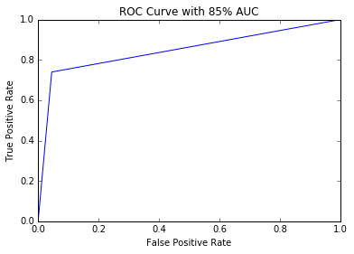

```python
import matplotlib.pyplot as plt
from sklearn.metrics import roc_auc_score
from sklearn import metrics
print "Area under the curve based on prediction:",roc_auc_score(testing_y,ypred_nb)
fpr_nb, tpr_nb, thresholds_nb = metrics.roc_curve(testing_y,ypred_nb)
print "False positive rate:",fpr_nb.tolist()
print "True positive rate:",tpr_nb.tolist()
print "threshold:", thresholds_nb
AUC_NaiveBayes=roc_auc_score(testing_y,ypred_nb)*100

plt.figure()
plt.plot(fpr_nb,tpr_nb)
plt.xlabel('False Positive Rate')
plt.ylabel('True Positive Rate')
plt.title('ROC Curve with 85% AUC')
```

```python
nbdf=pd.DataFrame([Accuracy_NaiveBayes,MAE_NaiveBayes,MSE_NaiveBayes,AUC_NaiveBayes],
                  index=('Accuracy_NaiveBayes %','MAE_NaiveBayes %','MSE_NaiveBayes %','AUC_NaiveBayes %'))
nbdf.transpose()

#####         Classifier prediction performance table
```

|  | Accuracy_NaiveBayes % | MAE_NaiveBayes % | MSE_NaiveBayes % | AUC_NaiveBayes % |
| --- | --- | --- | --- | --- |
| 0 | 89.400922 | 10.599078 | 10.599078 | 84.741066 |

## Decision Tree Classifier

```python
%matplotlib inline
from sklearn import tree
from sklearn.tree import DecisionTreeClassifier
from sklearn.tree import export_graphviz
```

```python
dec_tree=DecisionTreeClassifier()
dec_tree=dec_tree.fit(training_x,train_y)
names=['day of week','time of day', 'size.kb', 'box', 'local', 'digits', 'name field',
        'special','credit','sucker','porn','chain','usernum','large text']
y_predicted=dec_tree.predict(testing_x) # direct predction without referring to deicision tree
dec_tree
```

```
DecisionTreeClassifier(class_weight=None, criterion='gini', max_depth=None,
            max_features=None, max_leaf_nodes=None, min_samples_leaf=1,
            min_samples_split=2, min_weight_fraction_leaf=0.0,
            presort=False, random_state=None, splitter='best')
```

```python
from StringIO import StringIO
out = StringIO()
out = export_graphviz(dec_tree, out_file='C:\\Users\\tony stark\\Desktop\\data mining assignments\\proj 3\\notebook.dot',
                      filled=True, rounded=True,
                       special_characters=True)
```

**Accuracy**

```python
from sklearn.metrics import accuracy_score
print "The accuracy of our classifier is:",accuracy_score(testing_y, y_predicted)
Accuracy_tree=accuracy_score(testing_y, y_predicted)*100
```

```
The accuracy of our classifier is: 0.880184331797
```

**Error estimation**

```python
from sklearn.metrics import mean_absolute_error
from sklearn.metrics import mean_squared_error
print "Mean Absolute Error in the predication:",mean_absolute_error(testing_y, y_predicted)
print "Mean Squared Error in the predication:",mean_squared_error(testing_y, y_predicted)
MAE_tree=mean_absolute_error(testing_y, y_predicted)*100
MSE_tree=mean_squared_error(testing_y, y_predicted)*100
```

```
Mean Absolute Error in the predication: 0.119815668203
Mean Squared Error in the predication: 0.119815668203
```

**AUC Performance**

```
Area under the curve based on prediction: 0.87462421248
False positive rate: [0.0, 0.11254019292604502, 1.0]
True positive rate: [0.0, 0.8617886178861789, 1.0]
threshold: [2 1 0]
```

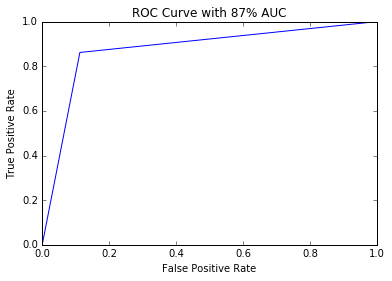

```python
import matplotlib.pyplot as plt
from sklearn.metrics import roc_auc_score
from sklearn import metrics
print "Area under the curve based on prediction:",roc_auc_score(testing_y, y_predicted)
fpr, tpr, thresholds = metrics.roc_curve(testing_y,y_predicted)
print "False positive rate:",fpr.tolist()
print "True positive rate:",tpr.tolist()
print "threshold:",thresholds
AUC_tree=metrics.roc_auc_score(testing_y,y_predicted)*100

plt.figure()
plt.plot(fpr,tpr)
plt.xlabel('False Positive Rate')
plt.ylabel('True Positive Rate')
plt.title('ROC Curve with 87% AUC')
```

This means that our classifier is pretty good in predicting the classes!

```python
trdf=pd.DataFrame([Accuracy_tree,MAE_tree,MSE_tree,AUC_tree],
                  index=('Accuracy_tree %','MAE_tree%','MSE_tree %','AUC_tree %'))
trdf.transpose()

#####         Classifier prediction performance table
```

|  | Accuracy_tree % | MAE_tree% | MSE_tree % | AUC_tree % |
| --- | --- | --- | --- | --- |
| 0 | 88.018433 | 11.981567 | 11.981567 | 87.462421 |

## Random Forest

```python
from sklearn.ensemble import RandomForestClassifier
rf = RandomForestClassifier()
rf=rf.fit(training_x,train_y)
ypred_rf =rf.predict(testing_x)

rf
```

```
RandomForestClassifier(bootstrap=True, class_weight=None, criterion='gini',
            max_depth=None, max_features='auto', max_leaf_nodes=None,
            min_samples_leaf=1, min_samples_split=2,
            min_weight_fraction_leaf=0.0, n_estimators=10, n_jobs=1,
            oob_score=False, random_state=None, verbose=0,
            warm_start=False)
```

**Accuracy**

```python
print "The accuracy of our classifier is:",accuracy_score(testing_y,ypred_rf)
Accuracy_Rforest=accuracy_score(testing_y,ypred_rf)*100
```

```
The accuracy of our classifier is: 0.923963133641
```

*it can be seen that the accuracy of the random forest is better than Decision Tree classifier*

**Error Estimation**

```python
print "Mean Absolute Error in the predication:",mean_absolute_error(testing_y, ypred_rf)
print "Mean Squared Error in the predication:",mean_squared_error(testing_y, ypred_rf)
MAE_Rforest=mean_absolute_error(testing_y, ypred_rf)*100
MSE_Rforest=mean_squared_error(testing_y, ypred_rf)*100
```

```
Mean Absolute Error in the predication: 0.0760368663594
Mean Squared Error in the predication: 0.0760368663594
```

**AUC Performance**

```
Area under the curve based on prediction: 0.915000130709
False positive rate: [0.0, 0.06430868167202572, 1.0]
True positive rate: [0.0, 0.8943089430894309, 1.0]
threshold: [2 1 0]
```

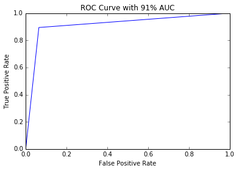

```python
print "Area under the curve based on prediction:",roc_auc_score(testing_y, ypred_rf)
fpr_rf, tpr_rf, thresholds_rf = metrics.roc_curve(testing_y, ypred_rf)
print "False positive rate:",fpr_rf.tolist()
print "True positive rate:",tpr_rf.tolist()
print "threshold:",thresholds_rf
AUC_Rforest=metrics.roc_auc_score(testing_y, ypred_rf)*100

plt.figure()
plt.plot(fpr_rf,tpr_rf)
plt.xlabel('False Positive Rate')
plt.ylabel('True Positive Rate')
plt.title('ROC Curve with 91% AUC')
```

```python
rfdf=pd.DataFrame([Accuracy_Rforest,MAE_Rforest,MSE_Rforest,AUC_Rforest],
                  index=('Accuracy_Rforest %','MAE_Rforest%','MSE_Rforest %','AUC_Rforest %'))
rfdf.transpose()

#####         Classifier prediction performance table
```

|  | Accuracy_Rforest % | MAE_Rforest% | MSE_Rforest % | AUC_Rforest % |
| --- | --- | --- | --- | --- |
| 0 | 92.396313 | 7.603687 | 7.603687 | 91.500013 |

From the above table it can be seen that Random forest is better than Decision Tree in predictions and Accuracy